# Dynamic lactation responses to dietary crude protein oscillation in diets adequate and deficient in metabolizable protein in Holstein cows - ScienceDirect

## [Journal of Dairy Science](https://www.sciencedirect.com/journal/journal-of-dairy-science)

[Volume 106, Issue 12](https://www.sciencedirect.com/journal/journal-of-dairy-science/vol/106/issue/12), December 2023, Pages 8774-8786

# Research Dynamic lactation responses to dietary crude protein oscillation in diets adequate and deficient in metabolizable protein in Holstein cows

https://doi.org/10.3168/jds.2023-23603[Get rights and content](https://s100.copyright.com/AppDispatchServlet?publisherName=ELS&contentID=S0022030223006100&orderBeanReset=true)

Under a Creative Commons [license](http://creativecommons.org/licenses/by/4.0/)

open access

## ABSTRACT

Limited research has examined the interaction between dietary crude protein (CP) level and CP feeding pattern. We tested CP level (low protein [LP], 13.8%; high protein [HP], 15.5% CP, dry matter [DM] basis) and CP feeding pattern (OF = oscillating, SF = static) using a 2 × 2 factorial in 16 mid- to late-lactation [Holsteins](https://www.sciencedirect.com/topics/agricultural-and-biological-sciences/holstein) (initially 128 ± 12 d in milk; mean ± SD). Cows ate [total mixed rations](https://www.sciencedirect.com/topics/agricultural-and-biological-sciences/total-mixed-ration) formulated by exchanging [soy](https://www.sciencedirect.com/topics/food-science/soybean) hulls and ground [corn](https://www.sciencedirect.com/topics/food-science/maize) with solvent [soybean meal](https://www.sciencedirect.com/topics/agricultural-and-biological-sciences/soybean-meal) to keep constant ratios of [neutral detergent fiber](https://www.sciencedirect.com/topics/agricultural-and-biological-sciences/neutral-detergent-fiber) to starch (1.18:1), rumen-degradable protein to CP (0.61:1), and forage-to-concentrate (1.5:1) in DM. The OF treatments alternated diets every 48 h to vary CP above and below the mean CP level (OF-LP = 13.8% ± 1.8%; OF-HP = 15.5% ± 1.8% CP [DM basis]) whereas diets were constant in SF (SF-LP = 13.8%; SF-HP = 15.5% CP [DM basis]). In four 28-d periods, 8 rumen-cannulated and 8 noncannulated cows formed 2 Latin rectangles. On d 25 to 28 of each period, each cow's feed intake and milk production were recorded, and samples were taken of orts (1×/d) and milk (2×/d). We fit linear mixed models with fixed CP level, CP feeding pattern, and period effects, and a random intercept for cow, computing least squares means and standard errors. Neither CP level, CP feeding pattern, nor the interaction affected [DM intake](https://www.sciencedirect.com/topics/agricultural-and-biological-sciences/dry-matter-intake), [feed efficiency](https://www.sciencedirect.com/topics/agricultural-and-biological-sciences/feed-efficiency), or production of milk, fat- and protein-corrected milk (FPCM), fat, true protein, or lactose. Milk urea-N (MUN) yield was lesser for LP. The LP and OF conditions decreased MUN concentration. The CP level tended to interact with CP feeding pattern so that [milk protein](https://www.sciencedirect.com/topics/agricultural-and-biological-sciences/milk-proteins) concentration was greatest for OF-HP. The OF and LP conditions increased the ratio of true protein to MUN yield. Within OF, cosinor mixed models of selected variables showed that cows maintained production of FPCM across dietary changes, but MUN followed a wave-pattern at a 2-d delay relative to dietary changes. A tendency for lesser MUN with OF contradicted prior research and suggested potential differences in urea-N metabolism between OF and SF. Results showed that cows maintained production of economically-relevant components regardless of CP feeding pattern and CP level. Contrary to our hypothesis, the effects of 48-h oscillating CP were mostly consistent across CP levels, suggesting that productivity is resilient to patterned variation in dietary CP over time even when average CP supply is low (13.8% of DM) and despite 48 h restrictions at 12.2% CP.

## GRAPHICAL ABSTRACT

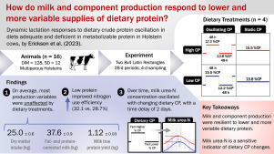

## Key words

dairy cow

nutrient variability

protein oscillation

performance

## INTRODUCTION

Most ruminant nutrition research considers the ability of constant-composition diets to meet daily [dietary protein](https://www.sciencedirect.com/topics/agricultural-and-biological-sciences/dietary-protein) requirements, yet ruminants rely on evolutionary mechanisms that theoretically cushion responses to dietary CP excesses and deficiencies spanning several days (Lapierre and Lobley, 2001). Researchers have attempted to leverage these physiological adaptations by altering CP feeding patterns between N excesses to deficiencies as a means to induce compensatory efficiency in growing sheep (Simpson, 2000; Kiran and Mutsvangwa, 2009; Doranalli et al., 2011), growing beef cattle (Ludden et al., 2003; Menezes et al., 2019a,b), and finishing beef cattle (Simpson, 2000; Cole et al., 2003; Archibeque et al., 2007). Several recent studies in mid-lactation dairy cattle observed limited changes to milk and component production, compared with static feeding, when the ingredient composition of 5% to 10% of dietary DM was alternated at regular intervals to create short-term restrictions in MP, RDP, or both MP and RDP (Brown, 2014; Kohler, 2016; Tebbe and Weiss, 2020; Rauch et al., 2021). In general, these studies showed that dairy cattle maintained performance when fed in oscillating patterns relative to static (Kohler, 2016; Tebbe and Weiss, 2020; Rauch et al., 2021) except when the duration and amplitude of nutrient changes was too severe (Brown, 2014).

Experiments that introduce variability in nutrient composition over time may contribute to empirical and mechanistic understanding of the extent to which putative N-conserving mechanisms can contribute to maintaining production during periods of deficiencies. However, existing studies on lactating cows have tested oscillating versus static CP feeding patterns centered at only 1 level of CP, and it remains unclear if the responses in productive performance are sensitive to level of CP interacting with CP feeding pattern. To address this limitation, our first objective was to evaluate performance responses in lactating dairy cows when consuming diets with different CP levels and feeding patterns. Our second objective was to characterize temporal patterns in production responses to the oscillating CP feeding pattern. We hypothesized that CP level and CP feeding pattern would interact such that the oscillating CP feeding pattern would be deleterious to productive performance at lower but not higher dietary CP.

## MATERIALS AND METHODS

This study occurred at the University of Wisconsin—Madison Dairy Cattle Center during April to August 2021. All procedures involving animals were approved by the University of Wisconsin–Madison Institutional Animal Care & Use Committee (protocol #A006439).

### Animals and Experimental Design

We used 16 multiparous [Holstein](https://www.sciencedirect.com/topics/agricultural-and-biological-sciences/holstein) cows (initially 128 ± 12 DIM; mean ± SD), where half of the cows were not cannulated (n = 8) and half were cannulated (n = 8; 10 cm ruminal cannula, Bar Diamond Inc., Parma, ID). Productive performance variables such as DMI, milk production, and component production were recorded for all cows (n = 16). This 2 × 2 factorial experiment consisted of four 28-d experimental periods. For each experimental period, cows were assigned to treatments within cannulated and noncannulated subsets in a replicated Latin rectangle arrangement. Each period consisted of an adaptation period (d 1–24) followed by a 4-d intensive sampling period (d 25–28). Two cows were removed from the study after contracting toxic mastitis, resulting in the loss of 2 cells (cow-periods) from the Latin rectangle. An additional cow was substituted into the design for period 3 to 4 after a toxic mastitis case in period 2. Throughout the experiment, cows were housed in individual tiestalls with rubber mats. Stalls were bedded with [wood shavings](https://www.sciencedirect.com/topics/agricultural-and-biological-sciences/wood-shavings). Cows were milked twice daily (0400 and 1600 h) and fed a TMR once daily (0800 h) targeting a 5% refusal rate. Feed was pushed toward cows in the bunk once daily (∼1800 h), and cows had free access to automatic waterers. The barn was cooled with an evaporative tunnel [ventilation system](https://www.sciencedirect.com/topics/agricultural-and-biological-sciences/ventilation-system).

### Dietary Treatments

Nutrient and ingredient composition is shown in Table 1, Table 2. Dietary treatments centered on 2 levels of CP (low protein [**LP**] = 13.8% of DM; high protein [**HP**] = 15.5% CP [DM basis]), with dietary [CP fed in](https://www.sciencedirect.com/topics/agricultural-and-biological-sciences/protein-in-feed) 2 patterns (oscillating or static, **OF** and **SF**, respectively). Using NRC (2001), we formulated LP to supply less than predicted requirements for RDP and MP and HP to supply adequate RDP and MP. Each OF feeding pattern alternated 2 diets every 48 h to vary CP above and below the mean CP level (OF-LP = 13.8% ± 1.8%; OF-HP = 15.5% ± 1.8% CP [DM basis]) resulting in time-varying dietary CP. In the SF feeding pattern, a single diet was fed throughout the experimental period for each dietary CP level, targeting time-invariant dietary CP (SF-LP = 13.8%; SF-HP = 15.5% CP [DM basis]). Dietary CP composition across an experimental period is shown in Figure 1. All diets had a 60:40 forage-to-concentrate ratio, with dietary changes implemented by changing the formulation of a pelleted concentrate blend, which included all ingredients except [corn](https://www.sciencedirect.com/topics/food-science/maize) silage and alfalfa haylage. [Forage composition](https://www.sciencedirect.com/topics/agricultural-and-biological-sciences/forage-composition) is shown in Table 3. [Soybean hulls](https://www.sciencedirect.com/topics/agricultural-and-biological-sciences/soybean-hulls), ground corn, and expeller [soybean meal](https://www.sciencedirect.com/topics/agricultural-and-biological-sciences/soybean-meal) were linearly exchanged with solvent soybean meal to alter dietary CP level. This exchange was designed to minimize differences in diet physical properties (particle size, anticipated ruminal digestion, and passage kinetics) and to hold constant dietary NDF:starch and RDP:CP ratios.

Table 1. Ingredient composition of diets used in oscillating (OF) and static (SF) feeding patterns at low (LP) and high (HP) CP levels, ingredient DM as a percentage of diet DM

| Item, % DM basis | OF-LP low phase | OF-HP low phase; SF-LP | OF-LP high phase; SF-HP | OF-HP high phase |
| --- | --- | --- | --- | --- |
| Corn silage | 47.00 | 47.00 | 47.00 | 47.00 |
| Alfalfa haylage | 13.00 | 13.00 | 13.00 | 13.00 |
| Ground corn (fine) | 14.00 | 12.00 | 10.00 | 8.00 |
| Soybean hulls | 10.50 | 8.00 | 5.50 | 3.00 |
| Solvent soybean meal | 3.00 | 8.00 | 13.00 | 18.00 |
| Expeller soybean meal<sup>1</sup> | 5.00 | 4.50 | 4.00 | 3.50 |
| Molasses | 2.70 | 2.70 | 2.70 | 2.70 |
| Animal/plant fat supplement<sup>2</sup> | 2.00 | 2.00 | 2.00 | 2.00 |
| Calcium carbonate | 0.80 | 0.80 | 0.80 | 0.80 |
| Sodium bicarbonate | 0.30 | 0.30 | 0.30 | 0.30 |
| Vitamin-mineral premix<sup>3</sup> | 0.10 | 0.10 | 0.10 | 0.10 |
| Potassium and magnesium sulfate<sup>4</sup> | 0.90 | 0.90 | 0.90 | 0.90 |
| Magnesium oxide<sup>5</sup> | 0.30 | 0.30 | 0.30 | 0.30 |
| Mono- and dicalcium phosphate<sup>6</sup> | 0.40 | 0.40 | 0.40 | 0.40 |

**1**

SoyPlus, Landus Cooperative, Ames, IA.

**2**

Energy Booster 100, Milk Specialties Global, Eden Prairie, MN.

**3**

The vitamin-mineral premix was commercially formulated to contain: 0.35% Ca, 82.12% NaCl, 0.09% S, 64 mg/kg Co, 4,831 mg/kg Cu, 381.6 mg/kg I, 1,472 mg/kg Fe, 14,250 mg/kg Mn, 76 mg/kg Se, 20,520 mg/kg Zn, 391,739 IU/kg [vitamin A](https://www.sciencedirect.com/topics/agricultural-and-biological-sciences/retinol), 78,348 IU/kg [vitamin D](https://www.sciencedirect.com/topics/agricultural-and-biological-sciences/vitamin-d), 1,958,693 IU/kg added [vitamin E](https://www.sciencedirect.com/topics/agricultural-and-biological-sciences/vitamin-e), 39.1 mg/kg biotin, 3.79 g/kg monensin, 0.68 g/kg diflubenzuron.

**4**

Commercially formulated for: 18% K, 11% Mg, 22% S.

**5**

Commercially formulated to contain: 56% Mg.

**6**

Commercially formulated to contain a minimum of: 18.5% P, 19.0% Ca.

Table 2. Nutrient composition of composite samples of each diet used in oscillating (OF) and static (SF) feeding patterns at low (LP) and high (HP) CP levels

| Nutrient<sup>1</sup> | OF-LP low phase (n = 4) | OF-HP low phase; SF-LP (n = 4) | OF-LP high phase; SF-HP (n = 4) | OF-HP high phase (n = 4) |
| --- | --- | --- | --- | --- |
| DM | 47.00 (1.71) | 46.51 (1.83) | 46.75 (1.47) | 46.36 (1.23) |
| OM | 95.85 (0.24) | 95.64 (0.60) | 95.71 (0.39) | 95.46 (0.27) |
| CP | 12.20 (0.27) | 13.78 (0.62) | 15.47 (0.79) | 17.26 (0.93) |
| ADF | 20.25 (0.93) | 19.53 (1.30) | 18.25 (1.57) | 17.64 (2.06) |
| ADFom | 19.87 (1.03) | 18.94 (1.21) | 17.69 (1.48) | 16.91 (2.08) |
| aNDF | 30.40 (1.43) | 28.45 (1.29) | 26.74 (2.02) | 26.29 (1.79) |
| aNDFom | 29.96 (1.50) | 27.89 (1.16) | 26.12 (1.92) | 25.54 (1.74) |
| ADICP | 0.69 (0.11) | 0.74 (0.35) | 0.64 (0.05) | 0.63 (0.09) |
| NDICP | 1.31 (0.02) | 1.29 (0.07) | 1.21 (0.07) | 1.16 (0.03) |
| WSC | 4.46 (0.38) | 4.91 (1.20) | 5.76 (0.53) | 5.34 (1.42) |
| Starch | 27.09 (3.29) | 25.21 (2.04) | 25.54 (2.72) | 24.67 (3.01) |
| Lignin | 3.06 (0.39) | 2.88 (0.42) | 3.03 (0.38) | 3.20 (0.42) |
| EE | 5.45 (0.26) | 5.12 (0.05) | 5.13 (0.21) | 5.13 (0.15) |

**1**

All nutrient composition is expressed as the mean (SD) in % of DM except when otherwise specified; ADFom = ADF corrected for ash content; aNDF = NDF using amylase and sodium sulfite; aNDFom = NDF corrected for ash content, using amylase and sodium sulfite; ADICP = acid detergent insoluble CP; NDICP = neutral detergent insoluble CP; WSC = water-soluble carbohydrates; EE = ether extract.

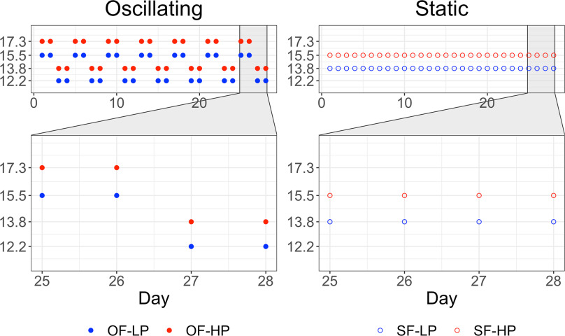

Figure 1. Dietary CP concentration (% of DM) at once daily feedings across a 28-d experimental period for 2 × 2 factorial combinations of CP feeding pattern and CP level: oscillating low protein (OF-LP), oscillating high protein (OF-HP), static low protein (SF-LP) static high protein (SF-HP). The 4-d intensive sampling frame (d 25 to 28) is highlighted.

Table 3. Nutrient composition of composite forage samples

| Nutrient<sup>1</sup> | Corn silage (n = 4) | Alfalfa haylage (n = 4) |
| --- | --- | --- |
| DM (% as-is) | 35.84 (1.68) | 35.45 (3.71) |
| OM | 99.86 (0.82) | 93.54 (1.41) |
| CP | 6.27 (0.66) | 20.30 (1.12) |
| ADF | 19.13 (0.94) | 28.13 (3.02) |
| ADFom | 18.23 (1.17) | 27.59 (3.34) |
| aNDF | 30.87 (1.18) | 34.45 (2.56) |
| aNDFom | 30.14 (1.20) | 33.53 (2.45) |
| ADICP | 0.65 (0.03) | 1.31 (0.08) |
| NDICP | 0.90 (0.11) | 1.83 (0.15) |
| WSC | 1.88 (0.38) | 2.18 (0.25) |
| Starch | 45.15 (3.68) | 2.32 (2.04) |
| Lignin | 2.72 (0.17) | 7.06 (0.86) |
| EE | 3.26 (0.65) | 4.83 (0.32) |

**1**

All nutrient composition is expressed as the mean (SD) % of DM except when otherwise specified; ADFom = ADF corrected for ash content; aNDF = NDF using amylase and sodium sulfite; aNDFom = NDF corrected for ash content, using amylase and sodium sulfite; ADICP = acid detergent insoluble CP; NDICP = neutral detergent insoluble CP; WSC = water-soluble carbohydrates; EE = ether extract.

### Measurements and Sampling

Cow BW were recorded before feeding and immediately after the 0400 h milking on d 22 to 23 of the experimental period and on d 1 to 2 of the subsequent period on a scale (Rice Lake Weighing Systems, Rice Lake, WI; Model 480Plus-2A). The same 3 raters scored body condition in 0.25 increments on a 1 to 5 scale on d 23 to d 28 of each experimental period (Wildman et al., 1982). Diets were mixed using a hydraulic cart (I.H. Rissler, Ephrata, PA; Mobile Forage Blender) equipped with an electronic scale (Avery Weigh-Tronix, Fairmont, MN; Model 640M). Samples of TMR, forages, and orts were oven-dried at 55°C for 48 h for sample preservation, and selected samples were further dried at 105°C for 24 h to determine DM. Once per week throughout the experiment, TMR and forage samples were taken and oven-dried to adjust ingredient amounts added to the feed mixer. For each intensive sampling period (d 25–28), daily samples of TMR (n = 4) and forages (n = 2) were frozen at −20°C. Batches of samples were thawed at room temperature, oven-dried, ground to pass a 1-mm screen in a Wiley Mill (Thomas Scientific, Swedesboro, NJ), and then composited by volume within diet and period. In each intensive sampling period, each cow's orts were sampled immediately before removing them. For a given cow and sampling period, orts from the high phase (d 25–26) and low phase (d 27–28) of the intensive sampling period were composited within-phase, as-is, by volume. Composited orts were oven-dried to enable gravimetric calculation of individual-cow DMI. Milk weights were collected using the parlor [flow meters](https://www.sciencedirect.com/topics/agricultural-and-biological-sciences/flowmeter) (Perfection 3000 Meter and Sampler, Boumatic, Madison, WI) and recorded manually by farm staff. Milk samples were taken via automatic samplers in the parlor, preserved with Bronopol tablets, and refrigerated 1 to 4 d until transportation for analysis.

### Laboratory Analysis

Analysis of total N, ash, NDF corrected for starch and ash (**aNDFom**), ADF corrected for ash (**ADFom**), and indigestible NDF corrected for ash (**iNDFom**) in feed occurred at the USDA Dairy Forage Research Center (Madison, WI). The procedure for NDF used a neutral detergent solution with amylase and sodium sulfite (method 2002.04.2005; Mertens, 2002). Residues from NDF and ADF procedures were ashed at 600°C for 2 h to determine NDFom and ADFom (method 973.18, AOAC International, 1996). Indigestible NDF (iNDFom) was determined following incubation of F57 polyester filter bags (25 micron porosity, 5 × 5 cm, 500-mg sample) for 240 h in the rumen of 2 cows fed a diet similar to experimental diets (major ingredients: alfalfa haylage, corn silage, corn grain). Feed samples were sent to a commercial laboratory for chemical analysis of the other reported nutrients (Dairyland Laboratories, Arcadia, WI). At the commercial laboratory, water-soluble [carbohydrates](https://www.sciencedirect.com/topics/food-science/carbohydrate) were measured using the method of Deriaz (1961), starch was assayed enzymatically (AOAC International, 2014), crude fat was determined with diethyl ether extraction (method 920.39, AOAC International, 1996), lignin was determined gravimetrically after neutral and acid detergent treatment and [sulfuric acid](https://www.sciencedirect.com/topics/agricultural-and-biological-sciences/sulfuric-acid) hydrolysis (method 973.18, AOAC International, 1996), and residues from the ADF and NDF procedures were combusted to determine acid detergent insoluble CP (ADICP) and neutral detergent insoluble CP, respectively (method 973.18, AOAC International, 1996). Milk samples were transported to a commercial laboratory for spectrometric analysis of components using a Foss FT6000 (Foss Electric, Hiller⊘d, Denmark; AgSource Laboratories, Verona, WI).

### Calculations, Data Processing, and Statistical Analysis

#### Missing Data Imputation

In addition to the 2 Latin rectangle cells removed due to toxic mastitis, a small percentage (0–2%) of milk weights and milk samples were missing due to technical issues such as failure of sampling equipment. To prevent imbalance across time points in the aggregate model, we used stochastic regression to impute these miscellaneous missing observations before aggregating to period-level means for each cow. The imputation model contained fixed effects and interactions for known experimental design factors including period (1, 2, 3, 4), milking (0400, 1600 h), and cow (1 to 17). Each prediction was augmented with a random draw from the observed residual distribution to mitigate variance attenuation (Little and Rubin, 2002).

#### Aggregation Methods

The DMI was calculated per cow for each day during the intensive sampling period, so it corresponded exactly with daily samples of TMR and orts. Then, we aggregated DMI to arithmetic means per cow, per period. Body weight was calculated as the arithmetic mean of n = 4 observations per cow, per period. The inter-rater reliability of BCS was evaluated using Cohen's kappa statistics with quadratic weights for the ordinal BCS scale. Results indicated moderate pairwise inter-rater reliabilities (*κw* = 0.50 to 0.61), so the arithmetic mean of BCS was used in further analyses (Cohen, 1968). The average milk component yield concentrations for a given cow and period were computed as weighted averages using the milk composition (%) and milk yield (kg) across morning (n = 4) and evening (n = 4) milkings in d 25 to 28 during each period.

### Statistical Analysis

Statistical analysis was conducted in R version 4.1.2 (R Core Team, 2021). We considered *P* < 0.05 significant and 0.05 ≤ *P* ≤ 0.10 tendencies. When standard errors (SE) differed due to imbalance, we reported the greatest SE.

### A Priori Contrasts for Productive Performance

For production and efficiency variables, we modeled the mean of observed values for a given cow and period using a linear mixed model with fixed effects for cannulation status (*S<sub>j</sub>*, where *j* = cannulated, noncannulated), experimental period (*E<sub>k</sub>*, where *k* = 1, 2, 3, 4), dietary CP level (*P<sub>l</sub>*, where *l* = LP, HP), CP feeding pattern (*F<sub>m</sub>*, where *m* = OF, SF), and the interaction term between CP level and CP feeding pattern (*PF<sub>lm</sub>*). We included a random effect of cow (*C<sub>i</sub>*, where *i* = 1 to 17) and a random error term (*ϵ<sub>ijklm</sub>*; n = 62). *y<sub>ijklm</sub>* = *μ* + *S<sub>j</sub>* + *E<sub>k</sub>* + *P<sub>l</sub>* + *F<sub>m</sub>* + *PF<sub>lm</sub>* + *C<sub>i</sub>* + *ϵ<sub>ijklm</sub>*, To model productive performance variables over time, we added fixed effects and all possible interactions for day (*D<sub>n</sub>*, where n = 25, 26, 27, 28) and hour (*H<sub>o</sub>*, where *o* = a.m. milking, p.m. milking) with treatments, and allowed the intercept to vary based on cow, period within cow, and day within period within cow, creating a block diagonal variance-covariance matrix: *y<sub>ijklmno</sub>* = *μ* + *S<sub>j</sub>* + *E<sub>k</sub>* + *P<sub>l</sub>* + *F<sub>m</sub>* + *PF<sub>lm</sub>* + *D<sub>n</sub>* + *H<sub>o</sub>* + (*D<sub>n</sub>* × *H<sub>o</sub>*) + *D<sub>n</sub>*(*P<sub>l</sub>* + *F<sub>m</sub>* + *PF<sub>lm</sub>*) + *H<sub>o</sub>*(*P<sub>l</sub>* + *F<sub>m</sub>* + *PF<sub>lm</sub>*) + (*D<sub>n</sub>* × *H<sub>o</sub>*)(*P<sub>l</sub>* + *F<sub>m</sub>* + *PF<sub>lm</sub>*) + *C<sub>i</sub>* + (*C*:*E*)*<sub>ik</sub>* + (*C*:*E*:*D*)*<sub>ikn</sub>* + *ϵ<sub>ijklmno</sub>*. We estimated models with [restricted maximum likelihood](https://www.sciencedirect.com/topics/agricultural-and-biological-sciences/restricted-maximum-likelihood) using the lme4 and lmerTest packages (Bates et al., 2015; Kuznetsova et al., 2017). We computed Type III sums of squares using the afex package (Singmann et al., 2022) to evaluate a priori contrasts comparing differences due to CP feeding pattern, CP level, and their interaction with F-tests. We estimated marginal means using the emmeans package (Lenth, 2016). To examine responses over time, we computed estimated marginal means for each treatment (CP level and CP feeding pattern) at each time point (day and hour) marginalized across experimental periods and cannulation status. For the subset of variables where the interaction of CP feeding pattern and day indicated a temporal pattern, we tested a cosinor model.

### Cosinor Analysis of Temporal Patterns in Milk Yield and Composition

For the oscillating CP feeding pattern, we tested if selected milk and component variables oscillated at a frequency set by dietary changes. Variables were selected on the basis of a significant CP feeding pattern by day interaction in linear models of productive performance over time. Because we were interested in differences over time for OF, we used only the subset of data when cows were fed the OF CP feeding pattern. We modeled the raw observed values for milk yield and composition at each milking (n = 8) during the intensive sampling period. We tested for oscillation in milk and component values assuming a 96-h period comprised of 2 feeding phases, the high-CP phase (d 25–26) and low-CP phase (d 27–28). With time centered at the time of the first feeding for the high-phase diets (d 25 at 0800 h), milk and component observations spanned −4 to 84 h (0400 and 1600 h daily) in each sampling period. We fit single component cosinor mixed models of the nonlinear form: $Yij=M+A×cos(2πtimeiperiod+ϕ)$where *Y<sub>ij</sub>* is the observed value of milk or component production for a given milking for cow *j*, *M* defines the rhythm-adjusted mean (**MESOR**), *A* represents the amplitude (half the extent of predicted variation in a cycle), *ϕ* is the acrophase (the time at which the function is maximized each cycle), and *ϵ<sub>ij</sub>* is the error term. We transformed time into 2 new variables, $ri=cos(2πtimeiperiod)$ and $si=sin(2πtimeiperiod),$ to estimate the nonlinear cosinor model using its equivalent linear form (Mikulich et al., 2003). The model included fixed effects that interacted with the 2 transformed-time variables to influence the MESOR, amplitude, and acrophase: experimental period (1, 2, 3, 4) and protein level (LP, HP). To correct for nuisance variation in milk and component production related to milking time (AM, PM), we added a fixed effect for sampling time that did not interact with transformed-time variables and thus influenced the MESOR but affected neither the amplitude nor acrophase. Finally, we included the random effect of cow (*C<sub>j</sub>*; affecting MESOR) of cow to account for cow-related variance. The observation *i* for cow *j* can be represented as a linear mixed model using the transformed-time parameters *r<sub>i</sub>* and *s<sub>i</sub>* as: *Y<sub>ij</sub>* = *M* + *α*<sub>0</sub>*E* + *α*<sub>1</sub>*S* + *α*<sub>2</sub>*H* + *α*<sub>3</sub>*P* + *α*<sub>4</sub>*H*:*P* + (*β* + *α*<sub>4</sub>*E* + *α*<sub>5</sub>*P*)*r<sub>i</sub>* + (*γ* + *α*<sub>6</sub>*E* + *α*<sub>7</sub>*P*)*s<sub>i</sub>* + *C<sub>j</sub>* + *ϵ<sub>ij</sub>*. We estimated cosinor models with restricted maximum likelihood using the lme4 package (Bates et al., 2015). To report model results, we converted acrophase from radians to hours as described by Refinetti et al. (2007) with $ϕ′=−ϕ(period2π).$ We used the “cosinoRmixedeffects” package to generate standard bootstrap confidence intervals for the nonlinear parameters MESOR, amplitude, acrophase, and for the pairwise differences in these parameters based on the covariate CP level (Hou et al., 2021).

## RESULTS AND DISCUSSION

Our study examined milk productive performance in response to 2 levels of dietary CP (LP, HP) and 2 CP feeding patterns (OF, SF) in a 2 × 2 factorial treatment arrangement. The LP treatments were designed using NRC (2001) to impose deficiencies in RDP and MP when averaged over time. Table 4 shows predicted supplies and balances of NEL and MP (NASEM, 2021). Consistent with our design of experimental diets, NASEM (2021) model predictions indicated that energy was oversupplied for all treatments, MP was undersupplied for LP (94% of requirement), and MP exceeded requirements for HP (104% of requirement). Because CP concentration varied ± 1.8% of DM in OF, predicted MP varied substantially for the higher- and lower-CP phases of oscillating treatments (OF-LP = 83–104% and OF-HP = 94–114% of MP requirement). Thus, our research contributed to understanding the potential interaction between CP level and feeding pattern suggested by prior research.

Table 4. Predicted supplies and requirements of net energy of lactation<sup>1</sup> and protein fractions for n = 16 cows fed combinations of CP: low protein (LP = 13.8% CP) or high protein (HP = 15.5% CP), with oscillating (OF, ± 1.8% CP at 48-h intervals) or static (SF) feeding patterns

| Nutrient | OF-LP low phase | OF-HP low phase; SF-LP | OF-LP high phase; SF-HP | OF-HP high phase |
| --- | --- | --- | --- | --- |
| NE<sub>L</sub>, Mcal/d |  |  |  |  |
| Supply | 45.5 | 45.6 | 45.6 | 45.6 |
| Requirement | 41.5 | 41.5 | 41.5 | 41.5 |
| Balance | 4.0 | 4.1 | 4.1 | 4.1 |
| MP, g/d |  |  |  |  |
| Supply | 1,880 | 2,113 | 2,343 | 2,569 |
| Requirement | 2,260 | 2,256 | 2,251 | 2,247 |
| Balance | −381 | −143 | 92 | 322 |
| MP from Microbes | 1,010 | 1,126 | 1,239 | 1,347 |
| MP from RUP | 869 | 987 | 1,104 | 1,222 |

**1**

Predicted with NASEM (2021) dairy-8 software using measured DMI, milk yield and composition, available feed composition, BW, DIM, and days in gestation for the study.

### DMI, BW, and BCS

We observed no differences in DMI due to CP level, CP feeding pattern, or the interaction (Table 5). Supplemental Figures S1, S2, and S3 (https://doi.org/10.5281/zenodo.8148356; Erickson et al., 2023) show DMI across the 4-d sampling period, which tended to differ slightly from day to day (*P* = 0.067; Table 5), but followed a similar temporal pattern for both OF and SF (D:F interaction, *P* = 0.314; Table 5). The lack of CP level effect on DMI in our trial may be related to the short duration of experimental periods (28-d) or the small magnitude of dietary changes. In a summary of contemporary studies, Sinclair et al. (2014) indicated that the effects of dietary CP on DMI were modest at dietary CP levels of 14% or greater and often confounded with changes in dietary fermentable energy and physical properties. In our trial, lower-CP coincided with modest increases in nonforage NDF and starch, with minimal changes in diet physical properties (constant forage:concentrate ratio) and no net effect on DMI.

Table 5. Milk and production performance across 4-d sampling for n = 16 cows fed combinations of low protein (LP = 13.8% of DM) or high protein (HP = 15.5% of DM), where diets alternated ± 1.8% CP every 2-d (oscillating; OF) or remained static (SF)<sup>1</sup>

| Item | LP OF | LP SF | HP OF | HP SF | SEM | Contrast (*P*) P | Contrast (*P*) F | Contrast (*P*) F:P | D | F:D | F:P:D |  |  |  |
| --- | --- | --- | --- | --- | --- | --- | --- | --- | --- | --- | --- | --- | --- | --- |
| DMI, kg/d | 24.9 | 24.8 | 25.4 | 24.8 | 0.7 | 0.60 | 0.42 | 0.56 |  |  |  | 0.07 | 0.31 | 0.12 |
| BW, kg | 661 | 665 | 671 | 667 | 16 | 0.28 | 0.95 | 0.44 |  |  |  |  |  |  |
| BCS | 3.11 | 3.14 | 3.17 | 3.13 | 0.07 | 0.29 | 0.64 | 0.30 |  |  |  |  |  |  |
| Milk yield, kg/d | 38.5 | 38.5 | 38.9 | 37.9 | 1.3 | 0.82 | 0.38 | 0.39 | 0.02 | <0.001 | 0.32 |  |  |  |
| FPCM<sup>2</sup>, kg/d | 37.1 | 37.6 | 38.1 | 37.4 | 1.1 | 0.60 | 0.90 | 0.38 | <0.001 | 0.00 | 0.05 |  |  |  |
| True protein, kg/d | 1.11 | 1.12 | 1.14 | 1.10 | 0.04 | 0.70 | 0.45 | 0.21 | 0.09 | <0.001 | 0.28 |  |  |  |
| Fat, kg/d | 1.53 | 1.57 | 1.58 | 1.57 | 0.05 | 0.48 | 0.70 | 0.56 | <0.001 | 0.06 | 0.08 |  |  |  |
| Lactose, kg/d | 1.80 | 1.80 | 1.82 | 1.77 | 0.07 | 0.75 | 0.28 | 0.40 | 0.04 | 0.00 | 0.28 |  |  |  |
| MUNY<sup>3</sup>, g/d | 3.36 | 3.51 | 4.56 | 4.68 | 0.15 | <0.001 | 0.17 | 0.91 | <0.001 | <0.001 | 0.50 |  |  |  |
| Milk energy, Mcal/d | 27.4 | 27.8 | 28.1 | 27.6 | 0.8 | 0.61 | 0.87 | 0.39 | <0.001 | 0.002 | 0.05 |  |  |  |
| Milk N, g/d | 175 | 177 | 181 | 174 | 6 | 0.58 | 0.47 | 0.21 | 0.11 | <0.001 | 0.28 |  |  |  |
| Milk composition |  |  |  |  |  |  |  |  |  |  |  |  |  |  |
| True protein, % | 2.88 | 2.91 | 2.93 | 2.90 | 0.04 | 0.24 | 0.79 | 0.09 | 0.05 | <0.001 | 0.94 |  |  |  |
| Fat, % | 4.02 | 4.10 | 4.13 | 4.17 | 0.12 | 0.29 | 0.50 | 0.83 | 0.02 | 0.65 | 0.45 |  |  |  |
| Lactose, % | 4.67 | 4.66 | 4.66 | 4.66 | 0.04 | 0.69 | 0.52 | 0.80 | 0.82 | 0.23 | 0.62 |  |  |  |
| MUN, mg/dL | 8.81 | 9.19 | 11.98 | 12.47 | 0.30 | <0.001 | 0.06 | 0.79 | <0.001 | <0.001 | 0.32 |  |  |  |
| Milk energy, Mcal/kg | 0.72 | 0.72 | 0.73 | 0.73 | 0.01 | 0.24 | 0.53 | 0.70 | 0.02 | 0.72 | 0.43 |  |  |  |

**1**

Results show LSM and contrasts for dietary CP level (P<sub>l</sub>, where *l* = LP, HP), CP feeding pattern (F<sub>m</sub>, where *m* = OF, SF), the interaction term between CP level and CP feeding pattern (F:P), day (D<sub>n</sub>, where n = 25, 26, 27, 28), and interactions of day with treatments (F:D and F:P:D).

**2**

FPCM = fat- and protein-corrected milk.

**3**

MUNY = MUN yield.

Similarly, in our trial, DMI was resilient to periodic small-magnitude dietary changes associated with the oscillating CP feeding pattern. This is consistent with recent studies of lactating cows that showed no effect of oscillating CP feeding pattern on DMI relative to static (Kohler, 2016; Tebbe and Weiss, 2020; Rauch et al., 2021). Because the oscillating pattern probably desynchronized the availability of RDP and [carbohydrates](https://www.sciencedirect.com/topics/food-science/carbohydrate), our results agree with the literature summarized by Hall and Huntington (2008) in which in vivo tests of asynchrony generally produced null results. The duration of higher- and lower-CP phases in our trial was expected to align with the approximate retention time of digesta in the gastrointestinal tract, as in earlier experiments on beef cattle and sheep (Cole, 1999). Effects of CP feeding pattern on DMI may also relate to changes in feeding behavior. For example, simultaneous and successive dietary variety have been shown to increase voluntary feed intake in rodents (Rolls et al., 1983), [pigs](https://www.sciencedirect.com/topics/agricultural-and-biological-sciences/pig) (Middelkoop et al., 2019), and [dairy heifers](https://www.sciencedirect.com/topics/agricultural-and-biological-sciences/dairy-heifers) (Meagher et al., 2017).

We noted no differences in BW or BCS due to CP level, CP feeding pattern, or the interaction. In our study, the magnitude of dietary changes, length of dietary adaptation (24-d), number of cows, and schedule of BW measurements was likely insufficient to detect treatment differences in BW. Liu et al. (2021) compared productive performance of [Holsteins](https://www.sciencedirect.com/topics/agricultural-and-biological-sciences/holstein) fed low (13%) and high (16%) CP, finding that low-CP reduced gains of BW and empty BW over 28- and 35-d periods in both peak and [late lactation](https://www.sciencedirect.com/topics/agricultural-and-biological-sciences/late-lactation), although the low-CP diet also reduced DMI in contrast to our study. Across our 112-d trial, linear effects for time showed that cows tended to lose a small amount of BW (−9.4 kg; *P* = 0.060) but gained condition score (+0.06, *P* < 0.001; Supplemental Tables S2 and S3, https://doi.org/10.5281/zenodo.8148356; Erickson et al., 2023). Thus, when averaging across LP and HP conditions for both CP feeding patterns, conditions generally supported production and maintenance without excessive mobilization or accretion of body reserves. In agreement with the lack of CP feeding pattern effect in our trial, recent research showed no differences in BW and BCS in dairy cattle between oscillating and static CP feeding patterns in short-term experiments lasting 25 to 60 d (Kohler, 2016; Tebbe and Weiss, 2020; Rauch et al., 2021). Tebbe and Weiss (2020) observed no differences in empty BW and urea space volume due to CP level (14.1% vs. 16.2% CP) or CP feeding pattern (Tebbe and Weiss, 2020). Considering the importance of protein reserves in the homeorhetic metabolic changes associated with lactation (McCabe and Boerman, 2020), longer-term research is warranted to assess the effects of [dietary protein](https://www.sciencedirect.com/topics/agricultural-and-biological-sciences/dietary-protein) and AA nutrition and CP feeding patterns in late lactation on body protein accumulation and subsequent lactation performance.

### Milk Yield and Composition

Milk and component production in general was similar across treatments (Table 5). The lack of CP level effect on productive performance contrasted recent change-over (Gonzalez Ronquillo et al., 2021) and parallel (Barros et al., 2017) studies where dietary CP was replaced with primarily starch and NDF, respectively. When increasing CP from 11.8% to 16.2% CP across 4 treatments with late-lactation cows, Barros et al. (2017) observed positive linear and negative quadratic CP effects on component yields, where the yield response to additional dietary CP gradually declined. Comparing 14.4% to 16.2% CP, Barros et al. (2017) found no statistical difference in yields of milk or FPCM. When increasing from 11.0% to 17.0% CP for mid-lactation cows, Gonzalez Ronquillo et al. (2021) found positive linear and negative quadratic responses in milk and protein yields where the 15.0% CP treatment maximized yields. Stevens et al. (2021) reported similar productive performance for [early lactation](https://www.sciencedirect.com/topics/agricultural-and-biological-sciences/early-lactation) multiparous cows fed 15.5% or 17.5% CP diets including supplemental RUP and rumen-protected [amino acids](https://www.sciencedirect.com/topics/food-science/amino-acids). In our study, decreasing CP from 15.5% to 13.8% had no effects on production variables of economic importance.

Although we found few differences in economically-relevant milk variables, we observed meaningful differences in MUN that may suggest differences in N metabolism. Diets with HP caused significantly greater MUN (12.2 vs. 9.0 mg/dL) and MUNY (4.62 vs. 3.44 g/d), which is consistent with previously reported values for diets with similar ingredient composition and CP level (Brito and Broderick, 2006; Olmos Colmenero and Broderick, 2006). We observed a tendency for lesser MUN with OF versus SF diets, which contrasts with previous literature where oscillating CP increased (Rauch et al., 2021) or tended to increase MUN (Kohler, 2016; Tebbe and Weiss, 2020). Differing CP feeding patterns (e.g., 24- vs. 48-h phase) and diets with different sites, rates, and extents of carbohydrate and protein degradation may affect ammonia absorption into blood, urea return to the gastrointestinal tract, and capture into ruminal [microbial protein](https://www.sciencedirect.com/topics/agricultural-and-biological-sciences/microbial-proteins) (Lapierre and Lobley, 2001). The reasons for differential MUN and MUNY responses to oscillating diets require further mechanistic investigation.

Importantly, our study used a change-over design, which may have dampened our ability to detect differences in certain production variables. Several meta-analyses (Huhtanen and Hetta, 2012; Zanton, 2016) and 1 prospective trial (Zanton, 2019) showed that most milk production variables responded rapidly-enough to dietary CP manipulation to be detected using a crossover design similar to our trial. However, Zanton (2019) observed carryover effects in [milk fat](https://www.sciencedirect.com/topics/agricultural-and-biological-sciences/milk-lipids) and consequently milk energy output with a CP manipulation similar to our trial, suggesting that longer-term studies may be required to detect production responses in these variables. Additionally, our trial included multiparous cows, whereas recent research showed that long-term lower-CP feeding could negatively affect productive performance of primiparous cows (Reynolds et al., 2016). Finally, because LP did not limit productivity, further study is required to determine if the effects of CP feeding pattern differ with more severe [CP deficiencies](https://www.sciencedirect.com/topics/agricultural-and-biological-sciences/protein-deficiencies).

### Milk Yield and Composition Over Time

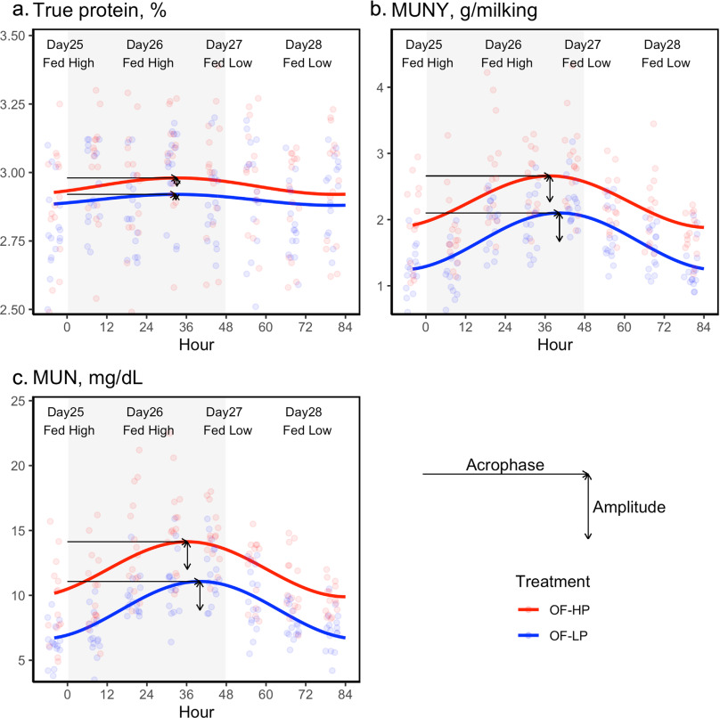

Table 6 shows the cosinor parameters amplitude and acrophase estimated for selected milk yield component variables. Figure 2 shows raw production data superimposed with cosinor least squares means production over the 4-d sampling period for these variables. Acrophase parameters are shown for variables with significant amplitudes (Table 6). In general, acrophase estimates suggested component production peaked near the 2 milkings preceding the dietary transition from higher-CP to lower-CP. The amplitude parameter was nonsignificant for yields of milk and FPCM. For other variables, nonzero amplitudes indicated that a wave-like pattern with 96 h period could be detected after controlling for covariates. Amplitude estimates indicated that milk true protein yield increased and decreased very slightly (0.01 kg/milking) relative to the MESOR when OF-LP was fed, but no 96 h wave-like pattern was apparent across the intensive sampling period for OF-HP-fed cows. Milk true protein concentration increased slightly (0.02%–0.03%) for both OF-LP and OF-HP fed cows following higher-CP-phase. In our trial, the lack of response in milk, FPCM, and protein yield to changes in oscillation phase may indicate that cows mobilized sufficient labile-N reserves to compensate for the transient dietary CP insufficiency, or instead that the lower-CP phases (12.2% and 13.8% CP for OF-LP and OF-HP treatments) provided adequate MP and AA supply to support similar production. This shows that regardless of dietary CP level, cows in our experiment sustained steady production of economically-relevant milk components despite regular dietary CP over- and under-sufficiency during oscillation phases.

Table 6. Results of single cosinor models for variables with a significant time by feeding pattern interaction (n = 248 observations from n = 16 cows)<sup>1</sup>

| Item | Amplitude<sup>2</sup> LP Est. | Amplitude<sup>2</sup> LP CI | Amplitude<sup>2</sup> HP Est. | Amplitude<sup>2</sup> HP CI | Amplitude<sup>2</sup> LP vs. HP *P* | Amplitude<sup>2</sup> LP Est. | Amplitude<sup>2</sup> LP CI | Acrophase,<sup>3</sup> h HP Est. | Acrophase,<sup>3</sup> h HP CI | Acrophase,<sup>3</sup> h LP vs. HP *P* |
| --- | --- | --- | --- | --- | --- | --- | --- | --- | --- | --- |
| Milk yield, kg/milking | 0.30 | (−0.03, 0.66) | 0.06 | (−0.33, 0.19) |  |  |  |  |  |  |
| FPCM<sup>4</sup>, kg/milking | 0.21 | (−0.23, 0.52) | 0.28 | (−0.31, 0.69) |  |  |  |  |  |  |
| True protein, kg/milking | 0.01 | (0.00, 0.02) | 0.00 | (−0.01, 0.01) | 0.21 | 42.6 | (28.9, 56.1) |  |  |  |
| Lactose, kg/milking | 0.01 | (0.00, 0.03) | 0.00 | (−0.02, 0.01) |  |  |  |  |  |  |
| MUNY<sup>5</sup>, g/milking | 0.43 | (0.35, 0.51) | 0.39 | (0.30, 0.48) | 0.58 | 40.3 | (37.7, 42.9) | 37.5 | (35.0, 40.2) | 0.15 |
| Milk energy, Mcal/milking | 0.15 | (−0.18, 0.37) | 0.21 | (−0.22, 0.52) |  |  |  |  |  |  |
| Milk N, g/milking | 2.34 | (0.79, 4.11) | 0.75 | (−0.80, 1.93) | 0.18 | 42.4 | (30.0, 54.6) |  |  |  |
| Milk composition |  |  |  |  |  |  |  |  |  |  |
| True protein, % | 0.02 | (0.00, 0.05) | 0.03 | (0.01, 0.05) | 0.77 | 32.8 | (25.0, 41.1) | 33.2 | (26.3, 40.8) | 0.95 |
| MUN, mg/dL | 2.21 | (1.87, 2.59) | 2.12 | (1.72, 2.54) | 0.77 | 40.0 | (37.7, 42.4) | 36.3 | (34.3, 38.5) | <0.001 |

**1**

LP = low protein; HP = high protein; Est. = parameter estimate. The LP versus HP contrast is only reported when an amplitude differed significantly from zero.

**2**

Amplitude is in the units of the analyte and represents half of the predicted range from nadir to peak.

**3**

Acrophase is the time of the peak expressed as hours after the first feeding of the high-phase diet. It is reported only when an amplitude differed significantly from zero.

**4**

FPCM = fat- and protein-corrected milk.

**5**

MUNY = MUN yield.

In our OF-LP condition, acrophase estimates suggested the slight increase in milk true protein yield and milk N production peaked at the milking immediately before the diet change (42.6–42.4 h). For both OF-LP and OF-HP, milk true protein concentration appeared to peak at the third of 4 milkings during the higher-CP oscillation phase (32.8–33.2 h), suggesting milk protein concentration rebounded more quickly than milk protein production after the resumption of higher-CP-phase feeding. Interestingly, Tebbe and Weiss (2020) reported increased milk and protein yields during the low-CP oscillation phase that suggested a delayed production response to dietary changes. In contrast, Rauch et al. (2021) showed a more immediate response where milk and component production gradually decreased during the low-CP phase with a nadir at the transition from low-CP to high-CP diets, then gradually increased during the high phase. Because several milk production variables rose and fell symmetrically with a peak near the oscillation phase transition in our trial, our results emphasize the importance of examining responses at the finest possible timescale (e.g., presenting results by milking rather than by period) to avoid obscuring meaningful within-period physiological changes when aggregating data across time.

Compared with other variables in our study, MUN and MUNY showed the largest and most immediate response to dietary changes, even after adaptation. The MUNY per milking was altered significantly across the duration of the oscillation phases (span of OF-LP = 0.43, OF-HP = 0.39 g), as was MUN (span of OF-LP = 2.21, OF-HP = 2.12 g). Based on the cosinor model, total milk N increased and decreased temporally by 2.34 g per milking for OF-LP, but no wave-like patterns matching the oscillation period were apparent in OF-HP, although these results did not differ from each other. Among variables with significant amplitude parameters, LP versus HP contrasts indicated amplitudes were similar across CP levels. For MUNY and MUN, where the most prominent oscillation pattern was visible, acrophase estimates suggested a peak near the third (OF-HP) or fourth (OF-LP) milking in the higher-CP phase. No differences between LP and HP amplitude and acrophase parameters were evident except with the MUN acrophase, which suggested that MUN concentration peaked later for LP than HP. Temporal patterns in group-average MUN have been proposed as an on-farm indicator of dietary CP adequacy (Powell et al., 2010) and limited evidence suggests that MUN may vary based on the adequacy of the absorbed AA profile (Appuhamy et al., 2011) in relation to requirements. Because MUN is strongly-correlated with urinary-N excretion, MUN-monitoring has the potential to decrease ammonia and nitrous oxide emissions (Burgos et al., 2007; Powell and Rotz, 2015), based on research with static CP diets. Our results support the assertion that dietary CP and MUN are positively related and that MUN can indicate minor (1.75% CP) and brief (24–48 h) changes in dietary CP even when cows have been adapted to time-varying diets.

## ACKNOWLEDGMENTS

This study was funded by Hatch Grants WIS04003 and WIS05009 (Washington, DC). This research was also supported by funding from the USDA Agricultural Research Service under National Program 101 Food Animal Production Current Research Information System (CRIS; Beltsville, Maryland) funds (project no. 5090-31000-026-00D). Mention of any trademark or proprietary product in this manuscript does not constitute a guarantee or warranty of the product by the USDA or the Agricultural Research Service and does not imply its approval to the exclusion of other products that also may be suitable. USDA is an equal opportunity provider and employer. We acknowledge Wendy Radloff and Mary Becker (US Dairy Forage Research Center; Madison, WI) for conducting chemical analysis of feeds. Finally, we thank the University of Wisconsin–Madison Dairy Cattle Center farm staff; and Paulina Letelier, Dante Pizarro, Kate Wells, Kaylee Riesgraf, Alyssa Seitz, Haden Hartwig, Siena Finlayson, and Sara Zentner for their assistance with sampling and laboratory analysis. The authors have not stated any conflicts of interest.

## REFERENCES

1. AOAC International, 1996

   AOAC International

   Official Methods of Analysis

   (16th ed.), Association of Official Analytical Chemists, Washington, D.C (1996)

   [Google Scholar](https://scholar.google.com/scholar_lookup?title=Official%20Methods%20of%20Analysis&publication_year=1996&author=AOAC%20International)
2. AOAC International, 2014

   AOAC International. 2014. AOAC Official Method 2014.10 Method Dietary Starch in Animal Feeds and Pet Food, Enzymatic-Colorimetric Method, First Action 2014.

   Google Scholar
3. Appuhamy et al., 2011

   J.A.D.R.N. Appuhamy, J.R. Knapp, O. Becvar, J. Escobar, M.D. Hanigan

   Effects of jugular-infused lysine, methionine, and branched-chain amino acids on milk protein synthesis in high-producing dairy cows

   J. Dairy Sci., 94 (2011), pp. 1952-1960

   https://doi.org/10.3168/jds.2010-3442

   21426986

   [View PDF](https://www.sciencedirect.com/science/article/pii/S0022030211001652/pdfft?md5=a5935bd27ebbf1febe94296bc37f906c&pid=1-s2.0-S0022030211001652-main.pdf)[View article](https://www.sciencedirect.com/science/article/pii/S0022030211001652)[CrossRef](https://doi.org/10.3168/jds.2010-3442)[View in Scopus](https://www.scopus.com/inward/record.url?eid=2-s2.0-79952751113&partnerID=10&rel=R3.0.0)Google Scholar
4. Archibeque et al., 2007

   S.L. Archibeque, H.C. Freetly, N.A. Cole, C.L. Ferrell

   The influence of oscillating dietary protein concentrations on finishing cattle. II. Nutrient retention and ammonia emissions

   J. Anim. Sci., 85 (2007), Article 1496

   https://doi.org/10.2527/jas.2006-208

   17264236

   Google Scholar
5. Barros et al., 2017

   T. Barros, M.A. Quaassdorff, M.J. Aguerre, J.J.O. Colmenero, S.J. Bertics, P.M. Crump, M.A. Wattiaux

   Effects of dietary crude protein concentration on late-lactation dairy cow performance and indicators of nitrogen utilization

   J. Dairy Sci., 100 (2017), pp. 5434-5448

   https://doi.org/10.3168/jds.2016-11917

   28501404

   [View PDF](https://www.sciencedirect.com/science/article/pii/S0022030217304083/pdfft?md5=b2c46c0d19a4de68e8d78626c7e120e4&pid=1-s2.0-S0022030217304083-main.pdf)[View article](https://www.sciencedirect.com/science/article/pii/S0022030217304083)[CrossRef](https://doi.org/10.3168/jds.2016-11917)[View in Scopus](https://www.scopus.com/inward/record.url?eid=2-s2.0-85019156518&partnerID=10&rel=R3.0.0)Google Scholar
6. Bates et al., 2015

   D. Bates, M. Mächler, B. Bolker, S. Walker

   Fitting linear mixed-effects models using lme4

   J. Stat. Softw., 67 (2015)

   https://doi.org/10.18637/jss.v067.i01

   [Google Scholar](https://scholar.google.com/scholar_lookup?title=Fitting%20linear%20mixed-effects%20models%20using%20lme4&publication_year=2015&author=D.%20Bates&author=M.%20M%C3%A4chler&author=B.%20Bolker&author=S.%20Walker)
7. Brito and Broderick, 2006

   A.F. Brito, G.A. Broderick

   Effect of varying dietary ratios of alfalfa silage to corn silage on production and nitrogen utilization in lactating dairy cows

   J. Dairy Sci., 89 (2006), pp. 3924-3938

   https://doi.org/10.3168/jds.S0022-0302(06)72435-3

   16960068

   [View PDF](https://www.sciencedirect.com/science/article/pii/S0022030206724353/pdfft?md5=1be7e1daae9b8ba91e7cc2ba1d9fa7d9&pid=1-s2.0-S0022030206724353-main.pdf)[View article](https://www.sciencedirect.com/science/article/pii/S0022030206724353)[View in Scopus](https://www.scopus.com/inward/record.url?eid=2-s2.0-33749421463&partnerID=10&rel=R3.0.0)Google Scholar
8. Brown, 2014

   A.N. Brown

   Effects of Oscillating Crude Protein Content of Dairy Cow Diets

   Master’s thesis.

   The Ohio State University, Animal Sciences, Columbus, Ohio (2014)

   http://rave.ohiolink.edu/etdc/view?acc_num=osu1406190341

   [Google Scholar](https://scholar.google.com/scholar_lookup?title=Effects%20of%20Oscillating%20Crude%20Protein%20Content%20of%20Dairy%20Cow%20Diets&publication_year=2014&author=A.N.%20Brown)
9. Burgos et al., 2007

   S.A. Burgos, J.G. Fadel, E.J. DePeters

   Prediction of ammonia emission from dairy cattle manure based on milk urea nitrogen: Relation of milk urea nitrogen to urine urea nitrogen excretion

   J. Dairy Sci., 90 (2007), pp. 5499-5508

   https://doi.org/10.3168/jds.2007-0299

   18024741

   [View PDF](https://www.sciencedirect.com/science/article/pii/S0022030207720234/pdfft?md5=96115fb0f84248de4576a7b8bf655df9&pid=1-s2.0-S0022030207720234-main.pdf)[View article](https://www.sciencedirect.com/science/article/pii/S0022030207720234)[CrossRef](https://doi.org/10.3168/jds.2007-0299)[View in Scopus](https://www.scopus.com/inward/record.url?eid=2-s2.0-37149050813&partnerID=10&rel=R3.0.0)Google Scholar
10. Cohen, 1968

    J. Cohen

    Weighted kappa: Nominal scale agreement provision for scaled disagreement or partial credit

    Psychol. Bull., 70 (1968), pp. 213-220

    https://doi.org/10.1037/h0026256

    19673146

    [CrossRef](https://doi.org/10.1037/h0026256)[View in Scopus](https://www.scopus.com/inward/record.url?eid=2-s2.0-58149412516&partnerID=10&rel=R3.0.0)[Google Scholar](https://scholar.google.com/scholar_lookup?title=Weighted%20kappa%3A%20Nominal%20scale%20agreement%20provision%20for%20scaled%20disagreement%20or%20partial%20credit&publication_year=1968&author=J.%20Cohen)
11. Cole, 1999

    N.A. Cole

    Nitrogen retention by lambs fed oscillating dietary protein concentrations

    J. Anim. Sci., 77 (1999), pp. 215-222

    https://doi.org/10.2527/1999.771215x

    10064047

    [CrossRef](https://doi.org/10.2527/1999.771215x)[View in Scopus](https://www.scopus.com/inward/record.url?eid=2-s2.0-0032610188&partnerID=10&rel=R3.0.0)[Google Scholar](https://scholar.google.com/scholar_lookup?title=Nitrogen%20retention%20by%20lambs%20fed%20oscillating%20dietary%20protein%20concentrations&publication_year=1999&author=N.A.%20Cole)
12. Cole et al., 2003

    N.A. Cole, L.W. Greene, F.T. Mccollum, T. Montgomery, K. Mcbride

    Influence of oscillating dietary crude protein concentration on performance, acid-base balance, and nitrogen excretion of steers

    J. Anim. Sci., 81 (2003), pp. 2660-2668

    [CrossRef](https://doi.org/10.2527/2003.81112660x)[View in Scopus](https://www.scopus.com/inward/record.url?eid=2-s2.0-1542757100&partnerID=10&rel=R3.0.0)Google Scholar
13. Deriaz, 1961

    R.E. Deriaz

    Routine analysis of carbohydrates and lignin in herbage

    J. Sci. Food Agric., 12 (1961), pp. 152-160

    https://doi.org/10.1002/jsfa.2740120210

    [CrossRef](https://doi.org/10.1002/jsfa.2740120210)[View in Scopus](https://www.scopus.com/inward/record.url?eid=2-s2.0-84982342346&partnerID=10&rel=R3.0.0)[Google Scholar](https://scholar.google.com/scholar_lookup?title=Routine%20analysis%20of%20carbohydrates%20and%20lignin%20in%20herbage&publication_year=1961&author=R.E.%20Deriaz)
14. Doranalli et al., 2011

    K. Doranalli, G.B. Penner, T. Mutsvangwa

    Feeding oscillating dietary crude protein concentrations increases nitrogen utilization in growing lambs and this response is partly attributable to increased urea transfer to the rumen

    J. Nutr., 141 (2011), pp. 560-567

    https://doi.org/10.3945/jn.110.133876

    21310865

    [View PDF](https://www.sciencedirect.com/science/article/pii/S0022316622025524/pdfft?md5=fbc639269fa1d5a82452ddab0cc69871&pid=1-s2.0-S0022316622025524-main.pdf)[View article](https://www.sciencedirect.com/science/article/pii/S0022316622025524)[CrossRef](https://doi.org/10.3945/jn.110.133876)[View in Scopus](https://www.scopus.com/inward/record.url?eid=2-s2.0-79955505072&partnerID=10&rel=R3.0.0)Google Scholar
15. Erickson et al., 2023

    M.G. Erickson, G.I. Zanton, M.A. Wattiaux

    Supplemental material for “Dynamic lactation responses to dietary crude protein oscillation in diets adequate and deficient in metabolizable protein in Holstein cows.” Zenodo

    https://doi.org/10.5281/zenodo.8148356 (2023)

    Google Scholar
16. Gonzalez Ronquillo et al., 2021

    M. Gonzalez Ronquillo, A.P. Faciola, H. Nursoy, G.A. Broderick

    Effect of increasing dietary protein with constant lysine:methionine ratio on production and omasal flow of nonammonia nitrogen in lactating dairy cows

    J. Dairy Sci., 104 (2021), pp. 5319-5331

    https://doi.org/10.3168/jds.2020-19541

    33663832

    [View PDF](https://www.sciencedirect.com/science/article/pii/S0022030221002228/pdfft?md5=99db2c478d38886d079cf386c6bcf156&pid=1-s2.0-S0022030221002228-main.pdf)[View article](https://www.sciencedirect.com/science/article/pii/S0022030221002228)[CrossRef](https://doi.org/10.3168/jds.2020-19541)[View in Scopus](https://www.scopus.com/inward/record.url?eid=2-s2.0-85101869095&partnerID=10&rel=R3.0.0)Google Scholar
17. Hall and Huntington, 2008

    M.B. Hall, G.B. Huntington

    Nutrient synchrony: Sound in theory, elusive in practice

    J. Anim. Sci., 86 (suppl_14) (2008), pp. E287-E292

    https://doi.org/10.2527/jas.2007-0516

    17965333

    [View in Scopus](https://www.scopus.com/inward/record.url?eid=2-s2.0-45949092871&partnerID=10&rel=R3.0.0)[Google Scholar](https://scholar.google.com/scholar_lookup?title=Nutrient%20synchrony%3A%20Sound%20in%20theory%2C%20elusive%20in%20practice&publication_year=2008&author=M.B.%20Hall&author=G.B.%20Huntington)
18. Hou et al., 2021

    R. Hou, L.E. Tomalin, M. Suárez-Fariñas

    cosinoRmixedeffects: An R package for mixed-effects cosinor models

    BMC Bioinformatics, 22 (2021), p. 553

    https://doi.org/10.1186/s12859-021-04463-3

    34773978

    [View in Scopus](https://www.scopus.com/inward/record.url?eid=2-s2.0-85119376793&partnerID=10&rel=R3.0.0)Google Scholar
19. Huhtanen and Hetta, 2012

    P. Huhtanen, M. Hetta

    Comparison of feed intake and milk production responses in continuous and change-over design dairy cow experiments

    Livest. Sci., 143 (2012), pp. 184-194

    https://doi.org/10.1016/j.livsci.2011.09.012

    [View PDF](https://www.sciencedirect.com/science/article/pii/S1871141311003313/pdfft?md5=15b12dfe363e3ffd36327feeab3ab5e6&pid=1-s2.0-S1871141311003313-main.pdf)[View article](https://www.sciencedirect.com/science/article/pii/S1871141311003313)[View in Scopus](https://www.scopus.com/inward/record.url?eid=2-s2.0-84855812721&partnerID=10&rel=R3.0.0)Google Scholar
20. IDF(International Dairy Federation), 2022

    IDF(International Dairy Federation). 2022. The IDF global carbon footprint standard for the dairy sector.

    Google Scholar
21. Kiran and Mutsvangwa, 2009

    D. Kiran, T. Mutsvangwa

    Nitrogen utilization in growing lambs fed oscillating dietary protein concentrations

    Anim. Feed Sci. Technol., 152 (2009), pp. 33-41

    https://doi.org/10.1016/j.anifeedsci.2009.03.009

    [View PDF](https://www.sciencedirect.com/science/article/pii/S0377840109000868/pdfft?md5=f5ee167c469adfe98076bf201e28acfe&pid=1-s2.0-S0377840109000868-main.pdf)[View article](https://www.sciencedirect.com/science/article/pii/S0377840109000868)[View in Scopus](https://www.scopus.com/inward/record.url?eid=2-s2.0-67349204795&partnerID=10&rel=R3.0.0)Google Scholar
22. Kohler, 2016

    J. Kohler

    The influence of oscillating dietary crude protein concentrations on milk production and nitrogen utilization in lactating dairy cows

    Master’s thesis.

    Agricultural and Bioresource Engineering, University of Saskatchewan, Saskatoon, SK, Canada (2016)

    https://harvest.usask.ca/handle/10388/7292?show=full

    Google Scholar
23. Kuznetsova et al., 2017

    A. Kuznetsova, P.B. Brockhoff, R.H.B. Christensen

    lmerTest Package: Tests in linear mixed effects models

    J. Stat. Softw., 82 (2017)

    https://doi.org/10.18637/jss.v082.i13

    Google Scholar
24. Lapierre and Lobley, 2001

    H. Lapierre, G.E. Lobley

    Nitrogen recycling in the ruminant: A review

    J. Dairy Sci., 84 (2001), pp. E223-E236

    https://doi.org/10.3168/jds.S0022-0302(01)70222-6

    [View PDF](https://www.sciencedirect.com/science/article/pii/S0022030201702226/pdf?md5=d2f242e6e916e8e2355bbe2128aa8d09&pid=1-s2.0-S0022030201702226-main.pdf)[View article](https://www.sciencedirect.com/science/article/pii/S0022030201702226)[Google Scholar](https://scholar.google.com/scholar_lookup?title=Nitrogen%20recycling%20in%20the%20ruminant%3A%20A%20review&publication_year=2001&author=H.%20Lapierre&author=G.E.%20Lobley)
25. Lenth, 2016

    R.V. Lenth

    Least-squares means: The R package lsmeans

    J. Stat. Softw., 69 (2016)

    https://doi.org/10.18637/jss.v069.i01

    [Google Scholar](https://scholar.google.com/scholar_lookup?title=Least-squares%20means%3A%20The%20R%20package%20lsmeans&publication_year=2016&author=R.V.%20Lenth)
26. Little and Rubin, 2002

    R.J.A. Little, D.B. Rubin

    Statistical Analysis with Missing Data

    John Wiley and Sons Inc., Hoboken, New Jersey (2002)

    https://doi.org/10.1002/9781119013563

    [Google Scholar](https://scholar.google.com/scholar_lookup?title=Statistical%20Analysis%20with%20Missing%20Data&publication_year=2002&author=R.J.A.%20Little&author=D.B.%20Rubin)
27. Liu et al., 2021

    E. Liu, M.D. Hanigan, M.J. VandeHaar

    Importance of considering body weight change in response to dietary protein deficiency in lactating dairy cows

    J. Dairy Sci., 104 (2021), pp. 11567-11579

    https://doi.org/10.3168/jds.2020-19566

    34419275

    [View PDF](https://www.sciencedirect.com/science/article/pii/S002203022100802X/pdfft?md5=b9080a2099eb3423d143c5ecd92b31c0&pid=1-s2.0-S002203022100802X-main.pdf)[View article](https://www.sciencedirect.com/science/article/pii/S002203022100802X)[CrossRef](https://doi.org/10.3168/jds.2020-19566)[View in Scopus](https://www.scopus.com/inward/record.url?eid=2-s2.0-85113772358&partnerID=10&rel=R3.0.0)Google Scholar
28. Ludden et al., 2003

    P.A. Ludden, T.L. Wechter, E.J. Scholljegerdes, B.W. Hess

    Effects of oscillating dietary protein on growth, efficiency, and serum metabolites in growing beef steers

    Prof. Anim. Sci., 19 (2003), pp. 30-34

    https://doi.org/10.15232/S1080-7446(15)31371-1

    [View PDF](https://www.sciencedirect.com/science/article/pii/S1080744615313711/pdf?md5=21c0a6593fbf1d601eca0da67fd99d9f&pid=1-s2.0-S1080744615313711-main.pdf)[View article](https://www.sciencedirect.com/science/article/pii/S1080744615313711)[View in Scopus](https://www.scopus.com/inward/record.url?eid=2-s2.0-85007552080&partnerID=10&rel=R3.0.0)Google Scholar
29. McCabe and Boerman, 2020

    C.J. McCabe, J.P. Boerman

    Invited review: Quantifying protein mobilization in dairy cows during the transition period

    Appl. Anim. Sci., 36 (2020), pp. 389-396

    https://doi.org/10.15232/aas.2019-01929

    [View PDF](https://www.sciencedirect.com/science/article/pii/S2590286520300720/pdfft?md5=de6622c3e360f3a5982f17be7e2d9759&pid=1-s2.0-S2590286520300720-main.pdf)[View article](https://www.sciencedirect.com/science/article/pii/S2590286520300720)[CrossRef](https://doi.org/10.15232/aas.2019-01929)[View in Scopus](https://www.scopus.com/inward/record.url?eid=2-s2.0-85085051267&partnerID=10&rel=R3.0.0)Google Scholar
30. Meagher et al., 2017

    R.K. Meagher, D.M. Weary, M.A.G. von Keyserlingk

    Some like it varied: Individual differences in preference for feed variety in dairy heifers

    Appl. Anim. Behav. Sci., 195 (2017), pp. 8-14

    https://doi.org/10.1016/j.applanim.2017.06.006

    [View PDF](https://www.sciencedirect.com/science/article/pii/S0168159117301831/pdfft?md5=7620b6aa784879a0cf1449dbbb8610b2&pid=1-s2.0-S0168159117301831-main.pdf)[View article](https://www.sciencedirect.com/science/article/pii/S0168159117301831)[View in Scopus](https://www.scopus.com/inward/record.url?eid=2-s2.0-85021081464&partnerID=10&rel=R3.0.0)Google Scholar
31. Menezes et al., 2019

    A.C.B. Menezes, S.C. V. Filho, P. Pucetti, M.V. C. Pacheco, L.A. Godoi, D. Zanetti, H.M. Alhadas, M.F. Paulino, J.S. Caton

    Oscillating and static dietary crude protein supply: II. Energy and protein requirements of young Nellore bulls

    Transl. Anim. Sci., 3 (2019), pp. 1216-1226

    https://doi.org/10.1093/tas/txz139

    32704885

    [CrossRef](https://doi.org/10.1093/tas/txz139)[View in Scopus](https://www.scopus.com/inward/record.url?eid=2-s2.0-85084608596&partnerID=10&rel=R3.0.0)Google Scholar
32. Menezes et al., 2019b

    A.C.B. Menezes, S.C. Valadares Filho, M.V.C. Pacheco, P. Pucetti, B.C. Silva, D. Zanetti, M.F. Paulino, F.F. Silva, T.L. Neville, J.S. Caton

    Oscillating and static dietary crude protein supply. I. Impacts on intake, digestibility, performance, and nitrogen balance in young Nellore bulls

    Transl. Anim. Sci., 3 (2019), pp. 1205-1215

    https://doi.org/10.1093/tas/txz138

    32704884

    [CrossRef](https://doi.org/10.1093/tas/txz138)[View in Scopus](https://www.scopus.com/inward/record.url?eid=2-s2.0-85084545683&partnerID=10&rel=R3.0.0)Google Scholar
33. Mertens, 2002

    D.R. Mertens

    Gravimetric determination of amylase-treated neutral detergent fiber in feeds with refluxing in beakers or crucibles: Collaborative study

    J. AOAC Int., 85 (2002), pp. 1217-1240

    12477183

    [View in Scopus](https://www.scopus.com/inward/record.url?eid=2-s2.0-0040673824&partnerID=10&rel=R3.0.0)Google Scholar
34. Middelkoop et al., 2019

    A. Middelkoop, M.A. van Marwijk, B. Kemp, J.E. Bolhuis

    Pigs like it varied; feeding behavior and pre- and post-weaning performance of piglets exposed to dietary diversity and feed hidden in substrate during lactation

    Front. Vet. Sci., 6 (2019), p. 408

    https://doi.org/10.3389/fvets.2019.00408

    31803769

    [View in Scopus](https://www.scopus.com/inward/record.url?eid=2-s2.0-85076695455&partnerID=10&rel=R3.0.0)Google Scholar
35. Mikulich et al., 2003

    S.K. Mikulich, G.O. Zerbe, R.H. Jones, T.J. Crowley

    Comparing linear and nonlinear mixed model approaches to cosinor analysis

    Stat. Med., 22 (2003), pp. 3195-3211

    https://doi.org/10.1002/sim.1560

    14518023

    [View in Scopus](https://www.scopus.com/inward/record.url?eid=2-s2.0-0141505956&partnerID=10&rel=R3.0.0)Google Scholar
36. NASEM (National Academies of Sciences, Engineering, and Medicine), 2021

    NASEM (National Academies of Sciences, Engineering, and Medicine)

    Nutrient Requirements of Dairy Cattle

    (Eighth Revised Edition), National Academies Press, Washington, DC (2021)

    Google Scholar
37. NRC (National Research Council), 2001

    NRC (National Research Council)

    Nutrient Requirements of Dairy Cattle

    (Seventh Revised Edition), National Academies Press, Washington, D.C. (2001)

    Google Scholar
38. Olmos Colmenero and Broderick, 2006

    J.J. Olmos Colmenero, G.A. Broderick

    Effect of dietary crude protein concentration on milk production and nitrogen utilization in lactating dairy cows

    J. Dairy Sci., 89 (2006), pp. 1704-1712

    https://doi.org/10.3168/jds.S0022-0302(06)72238-X

    16606741

    [View in Scopus](https://www.scopus.com/inward/record.url?eid=2-s2.0-33745894650&partnerID=10&rel=R3.0.0)Google Scholar
39. Powell and Rotz, 2015

    J.M. Powell, C.A. Rotz

    Measures of nitrogen use efficiency and nitrogen loss from dairy production systems

    J. Environ. Qual., 44 (2015), pp. 336-344

    https://doi.org/10.2134/jeq2014.07.0299

    26023953

    [CrossRef](https://doi.org/10.2134/jeq2014.07.0299)[View in Scopus](https://www.scopus.com/inward/record.url?eid=2-s2.0-84925453123&partnerID=10&rel=R3.0.0)Google Scholar
40. Powell et al., 2010

    J.M. Powell, C.J.P. Gourley, C.A. Rotz, D.M. Weaver

    Nitrogen use efficiency: A potential performance indicator and policy tool for dairy farms

    Environ. Sci. Policy, 13 (2010), pp. 217-228

    https://doi.org/10.1016/j.envsci.2010.03.007

    [View PDF](https://www.sciencedirect.com/science/article/pii/S1462901110000250/pdfft?md5=b6d06cb5dae8087d519dfe97ce40910b&pid=1-s2.0-S1462901110000250-main.pdf)[View article](https://www.sciencedirect.com/science/article/pii/S1462901110000250)[View in Scopus](https://www.scopus.com/inward/record.url?eid=2-s2.0-77952422419&partnerID=10&rel=R3.0.0)Google Scholar
41. R Core Team, 2021

    R Core Team

    R: A Language and Environment for Statistical Computing

    R Foundation for Statistical Computing, Vienna, Austria (2021)

    [Google Scholar](https://scholar.google.com/scholar_lookup?title=R%3A%20A%20Language%20and%20Environment%20for%20Statistical%20Computing&publication_year=2021&author=R%20Core%20Team)
42. Rauch et al., 2021

    R. Rauch, J. Martín-Tereso, J.B. Daniel, J. Dijkstra

    Dietary protein oscillation: Effects on feed intake, lactation performance, and milk nitrogen efficiency in lactating dairy cows

    J. Dairy Sci., 104 (2021), pp. 10714-10726

    https://doi.org/10.3168/jds.2021-20219

    34218916

    [View PDF](https://www.sciencedirect.com/science/article/pii/S0022030221007074/pdfft?md5=52bb431f80d2b3577c74b2f9bc3026a3&pid=1-s2.0-S0022030221007074-main.pdf)[View article](https://www.sciencedirect.com/science/article/pii/S0022030221007074)[CrossRef](https://doi.org/10.3168/jds.2021-20219)[View in Scopus](https://www.scopus.com/inward/record.url?eid=2-s2.0-85109036025&partnerID=10&rel=R3.0.0)Google Scholar
43. Refinetti et al., 2007

    R. Refinetti, G. Cornélissen, F. Halberg

    Procedures for numerical analysis of circadian rhythms

    Biol. Rhythm Res., 38 (2007), pp. 275-325

    https://doi.org/10.1080/09291010600903692

    23710111

    [CrossRef](https://doi.org/10.1080/09291010600903692)[View in Scopus](https://www.scopus.com/inward/record.url?eid=2-s2.0-34447269412&partnerID=10&rel=R3.0.0)[Google Scholar](https://scholar.google.com/scholar_lookup?title=Procedures%20for%20numerical%20analysis%20of%20circadian%20rhythms&publication_year=2007&author=R.%20Refinetti&author=G.%20Corn%C3%A9lissen&author=F.%20Halberg)
44. Reynolds et al., 2016

    C.K. Reynolds, L.A. Crompton, D.J. Humphries, A.K. Jones

    Long term implications of feeding low protein diets to first lactation dairy cows

    Proceedings of the 5th EAAP International Symposium on Energy and Protein Metabolism and Nutrition in Krakow, Poland on 12–15 September 2016 (2016)

    https://doi.org/10.3920/978-90-8686-832-2

    Google Scholar
45. Rolls et al., 1983

    B.J. Rolls, P.M. Van Duijvenvoorde, E.A. Rowe

    Variety in the diet enhances intake in a meal and contributes to the development of obesity in the rat

    Physiol. Behav., 31 (1983), pp. 21-27

    https://doi.org/10.1016/0031-9384(83)90091-4

    [View PDF](https://www.sciencedirect.com/science/article/pii/0031938483900914/pdf?md5=ebbbd1d28d7249da42458b36ce546488&pid=1-s2.0-0031938483900914-main.pdf)[View article](https://www.sciencedirect.com/science/article/pii/0031938483900914)[View in Scopus](https://www.scopus.com/inward/record.url?eid=2-s2.0-0020606446&partnerID=10&rel=R3.0.0)Google Scholar
46. Simpson, 2000

    S.J. Simpson

    Nitrogen utilization and performance in ruminants fed oscillating dietary protein levels. Animal and Poultry Sciences

    Virginia Polytechnic Institute and State University (2000)

    Google Scholar
47. Sinclair et al., 2014

    K.D. Sinclair, P.C. Garnsworthy, G.E. Mann, L.A. Sinclair

    Reducing dietary protein in dairy cow diets: Implications for nitrogen utilization, milk production, welfare and fertility

    Animal, 8 (2014), pp. 262-274

    https://doi.org/10.1017/S1751731113002139

    24290203

    [View PDF](https://www.sciencedirect.com/science/article/pii/S1751731113002139/pdf?md5=e447f88c1be1464a8470a7166b0621ea&pid=1-s2.0-S1751731113002139-main.pdf)[View article](https://www.sciencedirect.com/science/article/pii/S1751731113002139)[View in Scopus](https://www.scopus.com/inward/record.url?eid=2-s2.0-84892816735&partnerID=10&rel=R3.0.0)Google Scholar
48. Singmann et al., 2022

    H. Singmann, B. Bolker, J. Westfall, F. Aust, M.S. Ben-Shachar

    Afex: Analysis of Factorial Experiments

    [https://CRAN.R-project.org/package=afex](https://cran.r-project.org/package=afex) (2022)

    Google Scholar
49. Stevens et al., 2021

    A.V. Stevens, K. Karges, P. Rezamand, A.H. Laarman, G.E. Chibisa

    Production performance and nitrogen metabolism in dairy cows fed supplemental blends of rumen undegradable protein and rumen-protected amino acids in low- compared with high-protein diets containing corn distillers grains

    J. Dairy Sci., 104 (2021), pp. 4134-4145

    https://doi.org/10.3168/jds.2020-19697

    33612237

    [View PDF](https://www.sciencedirect.com/science/article/pii/S0022030221001776/pdfft?md5=4143542f24d8be25fe413d7d53605ff6&pid=1-s2.0-S0022030221001776-main.pdf)[View article](https://www.sciencedirect.com/science/article/pii/S0022030221001776)[CrossRef](https://doi.org/10.3168/jds.2020-19697)[View in Scopus](https://www.scopus.com/inward/record.url?eid=2-s2.0-85101138130&partnerID=10&rel=R3.0.0)Google Scholar
50. Tebbe and Weiss, 2020

    A.W. Tebbe, W.P. Weiss

    Effects of oscillating dietary crude protein concentrations on production, nutrient digestion, plasma metabolites, and body composition in lactating dairy cows

    J. Dairy Sci., 103 (2020), pp. 10219-10232

    https://doi.org/10.3168/jds.2020-18613

    32896402

    [View PDF](https://www.sciencedirect.com/science/article/pii/S0022030220306676/pdfft?md5=64fefc962ed77354d0308d1072027170&pid=1-s2.0-S0022030220306676-main.pdf)[View article](https://www.sciencedirect.com/science/article/pii/S0022030220306676)[CrossRef](https://doi.org/10.3168/jds.2020-18613)[View in Scopus](https://www.scopus.com/inward/record.url?eid=2-s2.0-85090306526&partnerID=10&rel=R3.0.0)Google Scholar
51. Wildman et al., 1982

    E.E. Wildman, G.M. Jones, P.E. Wagner, R.L. Boman, H.F. Troutt Jr., T.N. Lesch

    A dairy cow body condition scoring system and its relationship to selected production characteristics

    J. Dairy Sci., 65 (1982), pp. 495-501

    https://doi.org/10.3168/jds.S0022-0302(82)82223-6

    [View PDF](https://www.sciencedirect.com/science/article/pii/S0022030282822236/pdf?md5=5f2578a84317e6e4d4083723b79c79d2&pid=1-s2.0-S0022030282822236-main.pdf)[View article](https://www.sciencedirect.com/science/article/pii/S0022030282822236)[View in Scopus](https://www.scopus.com/inward/record.url?eid=2-s2.0-84990992540&partnerID=10&rel=R3.0.0)Google Scholar
52. Zanton, 2016

    G.I. Zanton

    Analysis of production responses to changing crude protein levels in lactating dairy cow diets when evaluated in continuous or change-over experimental designs

    J. Dairy Sci., 99 (2016), pp. 4398-4410

    https://doi.org/10.3168/jds.2015-10438

    27060818

    [View PDF](https://www.sciencedirect.com/science/article/pii/S0022030216301382/pdfft?md5=f332a3bad27c6e450298900749cbf42e&pid=1-s2.0-S0022030216301382-main.pdf)[View article](https://www.sciencedirect.com/science/article/pii/S0022030216301382)[CrossRef](https://doi.org/10.3168/jds.2015-10438)[View in Scopus](https://www.scopus.com/inward/record.url?eid=2-s2.0-84962720656&partnerID=10&rel=R3.0.0)Google Scholar
53. Zanton, 2019

    G.I. Zanton

    Effect of experimental design on responses to 2 concentrations of metabolizable protein in multiparous dairy cows

    J. Dairy Sci., 102 (2019), pp. 5094-5108

    https://doi.org/10.3168/jds.2018-15730

    30928268

    [View PDF](https://www.sciencedirect.com/science/article/pii/S0022030219303005/pdfft?md5=712b4fa91fc4daec153af1e11f21f0a3&pid=1-s2.0-S0022030219303005-main.pdf)[View article](https://www.sciencedirect.com/science/article/pii/S0022030219303005)[CrossRef](https://doi.org/10.3168/jds.2018-15730)[View in Scopus](https://www.scopus.com/inward/record.url?eid=2-s2.0-85063385628&partnerID=10&rel=R3.0.0)Google Scholar

## Cited by (0)

© 2023 The Author(s).

- Journal of Dairy Science, Volume 106, Issue 12, 2023, pp. 9440-9450

  Blair C. Downey, Cassandra B. Tucker

  [View PDF](https://www.sciencedirect.com/science/article/pii/S0022030223005817/pdfft?md5=25370250ebe27a62d0fabfaf1ee62546&pid=1-s2.0-S0022030223005817-main.pdf)

- Journal of Dairy Science, Volume 106, Issue 12, 2023, pp. 8926-8941

  B.A. Adamie, …, H. Hansson

  [View PDF](https://www.sciencedirect.com/science/article/pii/S0022030223005982/pdfft?md5=f4ba8a05c852003063e8d2f31181b0e1&pid=1-s2.0-S0022030223005982-main.pdf)

- Journal of Dairy Science, Volume 106, Issue 12, 2023, pp. 8723-8745

  I. Van Hese, …, G. Opsomer

  [View PDF](https://www.sciencedirect.com/science/article/pii/S0022030223005866/pdfft?md5=2764b0db277501c162408ceafb5b96e1&pid=1-s2.0-S0022030223005866-main.pdf)